# Práctica de Aprendizaje Supervisado

Alicia Aguirre

2018-04-08

#### Opción 1: Bank Marketing

```r
library(caret)
```

```r
library(data.table)
library(e1071)
library(rpart)
library(rpart.plot)
library(RColorBrewer)
library(h2o)
```

Carga del dataset, limpieza y separación de conjunto de train y test, así como visualización de la distribución de las variables.

```r
data <- read.csv("/home/usuario/Desktop/Aprendizaje supervisado/Practica/bank-additional.csv", sep = ";", stringsAsFactors = FALSE)
head(data)
```

```
##   age         job marital         education default housing    loan
## 1  30 blue-collar married          basic.9y      no     yes      no
## 2  39    services  single       high.school      no      no      no
## 3  25    services married       high.school      no     yes      no
## 4  38    services married          basic.9y      no unknown unknown
## 5  47      admin. married university.degree      no     yes      no
## 6  32    services  single university.degree      no      no      no
##     contact month day_of_week duration campaign pdays previous    poutcome
## 1  cellular   may         fri      487        2   999        0 nonexistent
## 2 telephone   may         fri      346        4   999        0 nonexistent
## 3 telephone   jun         wed      227        1   999        0 nonexistent
## 4 telephone   jun         fri       17        3   999        0 nonexistent
## 5  cellular   nov         mon       58        1   999        0 nonexistent
## 6  cellular   sep         thu      128        3   999        2     failure
##   emp.var.rate cons.price.idx cons.conf.idx euribor3m nr.employed  y
## 1         -1.8         92.893         -46.2     1.313      5099.1 no
## 2          1.1         93.994         -36.4     4.855      5191.0 no
## 3          1.4         94.465         -41.8     4.962      5228.1 no
## 4          1.4         94.465         -41.8     4.959      5228.1 no
## 5         -0.1         93.200         -42.0     4.191      5195.8 no
## 6         -1.1         94.199         -37.5     0.884      4963.6 no
```

```r
table(data$y)
```

```
##
##   no  yes
## 3668  451
```

```r
data$age <- as.numeric(data$age)
data$duration <- as.numeric(data$duration)
data$campaign <- as.numeric(data$campaign)
data$pdays <- as.numeric(data$pdays)
data$previous <- as.numeric(data$previous)
data$emp.var.rate <- as.numeric(data$emp.var.rate)
data$cons.price.idx <- as.numeric(data$cons.price.idx)
data$cons.conf.idx <- as.numeric(data$cons.conf.idx)
data$euribor3m <- as.numeric(data$euribor3m)
data$nr.employed <- as.numeric(data$nr.employed)
```

```r
data$job <- as.factor(data$job)
data$marital <- as.factor(data$marital)
data$education <- as.factor(data$education)
data$default <- as.factor(data$default)
data$housing <- as.factor(data$housing)
data$loan <- as.factor(data$loan)
data$contact <- as.factor(data$contact)
data$month <- as.factor(data$month)
data$day_of_week <- as.factor(data$day_of_week)
data$poutcome <- as.factor(data$poutcome)
data$y <- as.factor(data$y)
```

Para la mejora predictiva eliminamos la variable duration puesto que esta altamente correlada con la variable a predecir.

```r
data <- subset(data, select = -c(duration))
```

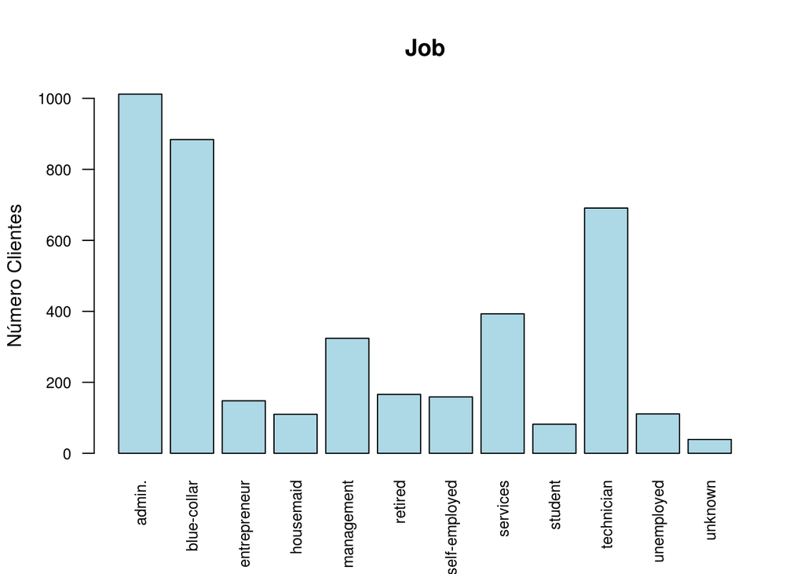

```r
barplot(table(data$job),col="light blue",ylab="Número Clientes",las=2,main="Job",cex.names = 0.8,cex.axis = 0.8)
```

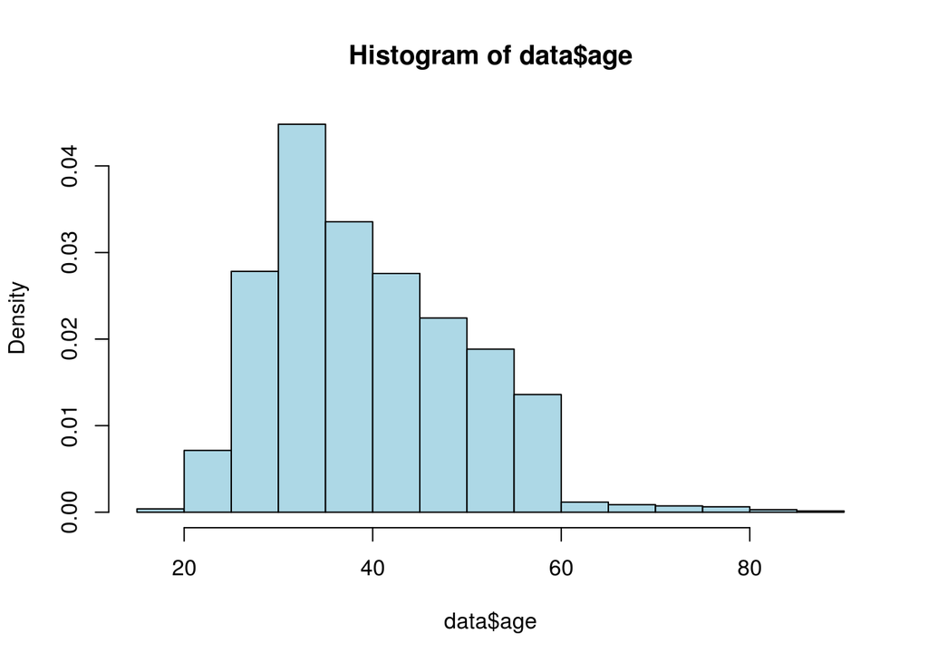

```r
hist(data$age, col = "light blue", freq = FALSE)
```

```r
set.seed(123456)
TrainingData <- createDataPartition(data$y, p=0.75, list = FALSE)
train <- data[TrainingData,]
test <-data[-TrainingData,]
```

```r
prop.table(table(train$y))
```

```
##
##        no       yes
## 0.8902913 0.1097087
```

```r
nrow(train)
```

```
## [1] 3090
```

```r
prop.table(table(test$y))
```

```
##
##        no       yes
## 0.8911565 0.1088435
```

```r
nrow(test)
```

```
## [1] 1029
```

Vemos que se mantiene la distribución de yes y no en ambos subconjuntos de datos.

#### SVM: Predecir si el cliente va a contratar el depósito.

Train

```r
train.SVM <- subset(train, select = -c(y))
train.SVM <- data.frame(x = train.SVM, y = as.factor(train$y))
```

```r
out.svm <- svm(y ~ ., data = train.SVM, kernel = "linear", cost = 1)
summary(out.svm)
```

```
##
## Call:
## svm(formula = y ~ ., data = train.SVM, kernel = "linear", cost = 1)
##
##
## Parameters:
##    SVM-Type:  C-classification
##  SVM-Kernel:  linear
##        cost:  1
##       gamma:  0.01886792
##
## Number of Support Vectors:  1501
##
##  ( 1189 312 )
##
##
## Number of Classes:  2
##
## Levels:
##  no yes
```

```r
table(out.svm$fitted, train$y)
```

```
##
##         no  yes
##   no  2703  258
##   yes   48   81
```

Test

```r
test.SVM <- subset(test, select = -c(y))
test.SVM <- data.frame(x = test.SVM, y= as.factor(test$y))
pred.test.SVM <- predict(out.svm, newdata = test.SVM)
```

Validation

```r
table(pred.test.SVM, test.SVM$y)
```

```
##
## pred.test.SVM  no yes
##           no  905  93
##           yes  12  19
```

La predicción de ‘no’ es bastante buena, pero la de ‘si’ no llega a ser tan buena. Vamos a intentar mejorarlo

```r
prop.table(table(pred.test.SVM, test.SVM$y))
```

```
##
## pred.test.SVM         no        yes
##           no  0.87949466 0.09037901
##           yes 0.01166181 0.01846453
```

Optimización y mejora predictiva:

```r
#En primer lugar normalizamos las varibles para que converja mas facilmente el algoritmo.
normalize <- function(x) {
  return ((x - min(x)) / (max(x) - min(x)))
}
```

```r
data$age <- normalize(data$age)
data$campaign <- normalize(data$campaign)
data$pdays <- normalize(data$pdays)
data$previous <- normalize(data$previous)
data$emp.var.rate <- normalize(data$emp.var.rate)
data$cons.price.idx <- normalize(data$cons.price.idx)
data$cons.conf.idx <- normalize(data$cons.conf.idx)
data$euribor3m <- normalize(data$euribor3m)
data$nr.employed <- normalize(data$nr.employed)
```

```r
set.seed(123456)
TrainingData <- createDataPartition(data$y, p=0.75, list = FALSE)
train <- data[TrainingData,]
test <-data[-TrainingData,]
```

```r
#Utilizamos TUNE para realizar cross-validation y saber el valor de coste optimo para SVM.

tune.out <- tune(svm, y ~ ., data = train, kernel = "linear",
                 ranges = list(cost = c(seq(0.01, 0.2, by = 0.01))),
                 tunecontrol = tune.control(sampling = "cross", cross = 10))

summary(tune.out)
```

```
##
## Parameter tuning of 'svm':
##
## - sampling method: 10-fold cross validation
##
## - best parameters:
##  cost
##  0.01
##
## - best performance: 0.09902913
##
## - Detailed performance results:
##    cost      error dispersion
## 1  0.01 0.09902913 0.02334687
## 2  0.02 0.09902913 0.02334687
## 3  0.03 0.09902913 0.02334687
## 4  0.04 0.09902913 0.02334687
## 5  0.05 0.09902913 0.02334687
## 6  0.06 0.09902913 0.02334687
## 7  0.07 0.09902913 0.02334687
## 8  0.08 0.09902913 0.02334687
## 9  0.09 0.09902913 0.02334687
## 10 0.10 0.09902913 0.02334687
## 11 0.11 0.09902913 0.02334687
## 12 0.12 0.09902913 0.02334687
## 13 0.13 0.09902913 0.02334687
## 14 0.14 0.09902913 0.02334687
## 15 0.15 0.09902913 0.02334687
## 16 0.16 0.09902913 0.02334687
## 17 0.17 0.09902913 0.02334687
## 18 0.18 0.09902913 0.02334687
## 19 0.19 0.09902913 0.02334687
## 20 0.20 0.09902913 0.02334687
```

```r
bestmodal.tune<-tune.out$best.model
summary(bestmodal.tune)
```

```
##
## Call:
## best.tune(method = svm, train.x = y ~ ., data = train, ranges = list(cost = c(seq(0.01,
##     0.2, by = 0.01))), tunecontrol = tune.control(sampling = "cross",
##     cross = 10), kernel = "linear")
##
##
## Parameters:
##    SVM-Type:  C-classification
##  SVM-Kernel:  linear
##        cost:  0.01
##       gamma:  0.01886792
##
## Number of Support Vectors:  933
##
##  ( 617 316 )
##
##
## Number of Classes:  2
##
## Levels:
##  no yes
```

No obtenemos diferencias para el valor de coste, aun así el mejor es el más pequeño: cost=0.01

```r
#Probaremos ahora con kernel = polynomial y cost=0.01
train.svm<-svm(y~.,train,kernel="polynomial",cost=0.01,scale=TRUE,degree=3,gamma=0.1)
summary(train.svm)
```

```
##
## Call:
## svm(formula = y ~ ., data = train, kernel = "polynomial", cost = 0.01,
##     degree = 3, gamma = 0.1, scale = TRUE)
##
##
## Parameters:
##    SVM-Type:  C-classification
##  SVM-Kernel:  polynomial
##        cost:  0.01
##      degree:  3
##       gamma:  0.1
##      coef.0:  0
##
## Number of Support Vectors:  860
##
##  ( 545 315 )
##
##
## Number of Classes:  2
##
## Levels:
##  no yes
```

```r
#Testing
test.svm<-predict(train.svm,test)
```

```r
#Misclassification Table
table(predict=test.svm,truth=test$y)
```

```
##        truth
## predict  no yes
##     no  910  96
##     yes   7  16
```

#### Decision Trees: Predecir si el cliente va a contratar el depósito.

```r
#Inicializamos de nuevo la varible data para que no influyan los cambios hechos posteriormente en el caso anterior.

data <- read.csv("/home/usuario/Desktop/Aprendizaje supervisado/Practica/bank-additional.csv", sep = ";", stringsAsFactors = FALSE)

data$age <- as.numeric(data$age)
data$duration <- as.numeric(data$duration)
data$campaign <- as.numeric(data$campaign)
data$pdays <- as.numeric(data$pdays)
data$previous <- as.numeric(data$previous)
data$emp.var.rate <- as.numeric(data$emp.var.rate)
data$cons.price.idx <- as.numeric(data$cons.price.idx)
data$cons.conf.idx <- as.numeric(data$cons.conf.idx)
data$euribor3m <- as.numeric(data$euribor3m)
data$nr.employed <- as.numeric(data$nr.employed)

data$job <- as.factor(data$job)
data$marital <- as.factor(data$marital)
data$education <- as.factor(data$education)
data$default <- as.factor(data$default)
data$housing <- as.factor(data$housing)
data$loan <- as.factor(data$loan)
data$contact <- as.factor(data$contact)
data$month <- as.factor(data$month)
data$day_of_week <- as.factor(data$day_of_week)
data$poutcome <- as.factor(data$poutcome)
data$y <- as.factor(data$y)

set.seed(123456)
TrainingData <- createDataPartition(data$y, p=0.75, list = FALSE)
train <- data[TrainingData,]
test <-data[-TrainingData,]
```

Train

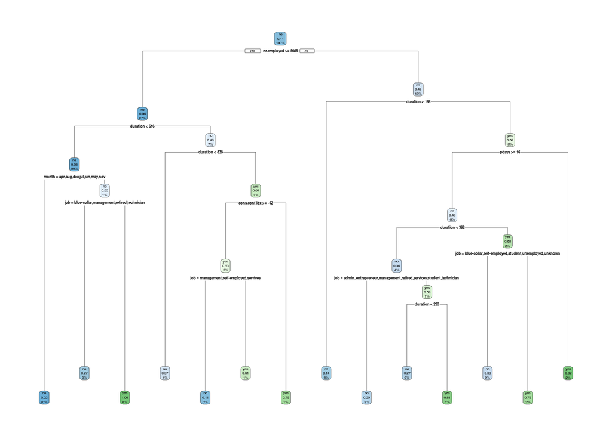

```r
data.rpart <- rpart(y ~ ., data = train, cp = 10^(-2))
rpart.plot(data.rpart)
```

Test

```r
predictions <- predict(data.rpart, test, type = "class")
```

Validation

```r
confusion.matrix <- table(predictions, test$y)
confusion.matrix
```

```
##
## predictions  no yes
##         no  895  66
##         yes  22  46
```

Las predicciones son bastante aceptables. Veamos la precisión.

```r
confusion.matrix <- prop.table(table(predictions, test$y))
accuracy <- confusion.matrix[1,1] + confusion.matrix[2,2]
accuracy
```

```
## [1] 0.9144801
```

Optimización y mejora predictiva

```r
#Veamos los nombres de la variable retornada
names(data.rpart)
```

```
##  [1] "frame"               "where"               "call"
##  [4] "terms"               "cptable"             "method"
##  [7] "parms"               "control"             "functions"
## [10] "numresp"             "splits"              "csplit"
## [13] "variable.importance" "y"                   "ordered"
```

```r
#El atributo cptable nos aporta informacion del tamaño del arbol y el error
data.rpart$cptable[,]
```

```
##           CP nsplit rel error    xerror       xstd
## 1 0.05899705      0 1.0000000 1.0000000 0.05124674
## 2 0.04719764      2 0.8820059 1.0235988 0.05177245
## 3 0.03982301      4 0.7876106 0.9705015 0.05057690
## 4 0.01474926      6 0.7079646 0.7876106 0.04607148
## 5 0.01179941      8 0.6784661 0.8289086 0.04714657
## 6 0.01032448      9 0.6666667 0.8407080 0.04744713
## 7 0.01000000     13 0.6253687 0.8436578 0.04752182
```

Variando el parámetro cp podemos cambiar la profundidad del arbol y ver como afecta dicha profundidad en el error de los útlimos árboles.

- 1º-> cp = 10^(-6): Accuracy 0.9173955
- 2º-> cp = 10^(-2): Accuracy 0.9144801

Tenemos un accuracy más bajo para cp 10-2 pero con menos spits podemos explicar el resultado casi con la misma precisión.

```r
# Interpetación de resultados
data.rpart$frame[,]
```

```
##               var    n   wt dev yval  complexity ncompete nsurrogate
## 1     nr.employed 3090 3090 339    1 0.058997050        4          5
## 2        duration 2690 2690 170    1 0.039823009        4          0
## 4           month 2481 2481  67    1 0.010324484        4          2
## 8          <leaf> 2459 2459  56    1 0.000000000        0          0
## 9             job   22   22  11    1 0.010324484        4          5
## 18         <leaf>   15   15   4    1 0.010000000        0          0
## 19         <leaf>    7    7   0    2 0.010000000        0          0
## 5        duration  209  209 103    1 0.039823009        4          5
## 10         <leaf>  114  114  42    1 0.008849558        0          0
## 11  cons.conf.idx   95   95  34    2 0.010324484        4          5
## 22            job   53   53  25    2 0.010324484        4          2
## 44         <leaf>    9    9   1    1 0.010000000        0          0
## 45         <leaf>   44   44  17    2 0.008849558        0          0
## 23         <leaf>   42   42   9    2 0.000000000        0          0
```

[output cut: 69 more lines]

```r
data.rpart$splits[,]
```

[output not shown]

[output cut: 58 more lines]

[output not shown]

```r
data.rpart$csplit[,]
```

[output not shown]

[output cut: 34 more lines]

#### Neural Networks: Modelo de regresión para predecir la edad

Train

```r
data$age <- normalize(data$age)
data$campaign <- normalize(data$campaign)
data$pdays <- normalize(data$pdays)
data$previous <- normalize(data$previous)
data$emp.var.rate <- normalize(data$emp.var.rate)
data$cons.price.idx <- normalize(data$cons.price.idx)
data$cons.conf.idx <- normalize(data$cons.conf.idx)
data$euribor3m <- normalize(data$euribor3m)
data$nr.employed <- normalize(data$nr.employed)
```

```r
TrainingData <- createDataPartition(data$y, p=0.75, list = FALSE)
train <- data[TrainingData,]
test <-data[-TrainingData,]
```

```r
localH2O = h2o.init(nthreads=-1)
```

[output not shown]

```r
train.hex <- as.h2o(train)
test.hex <- as.h2o(test)
h2o.model <- h2o.deeplearning(x = 2:20, y = 1, training_frame = train.hex,
                              hidden = c(3, 2, 3, 3), seed = 1234,
                              activation = "Tanh",
                              stopping_rounds = 20,
                              validation_frame = test.hex,
                              standardize = T, epochs = 10000,
                              train_samples_per_iteration = 0)
```

Test

```r
predictions <- as.vector(h2o.predict(h2o.model, test.hex))
```

Validation

```r
cor(predictions, test$age)
```

```
## [1] 0.5839791
```

```r
RMSE <- sqrt(mean((test$age - predictions)^2))
RMSE
```

```
## [1] 0.117161
```